# Assignment #5

Data Analysis with Applications

JiSeong Han

20 5월, 2024

### Handwritten Digit Recognition

MNIST 데이터셋은 image classification model의 성능을 평가하는 데 주로 활용되는 데이터셋으로, 아래 예와 같이 손으로 쓰여진 숫자들의 이미지 70,000개로 구성되어 있다. 이 중에서 60,000개는 training set으로 활용 되며 10,000개는 test set으로 활용된다. 각 데이터는 28 * 28 = 784개의 픽셀의 명암을 0~255 사이의 값으로 표현한 784개의 feature와 0~9 사이의 숫자로 표현되는 target을 포함한다. 본 과제에서는 tree를 활용하여 숫자를 분류하기 위한 classification model을 만들어본다.

```r
# 라이브러리 추가
library(caret)
library(dslabs)
library(rpart)
library(rpart.plot)
library(randomForest)
```

#### 1. 아래의 순서에 따라 data preprocessing을 수행하자.

**A. dslabs 패키지를 설치하고, 다음 코드를 실행하면 mnist 변수에 아래 설명과 같이 데이터가 저장된다.**

```r
# 1A. mnist 데이터 읽기
mnist <- read_mnist()
```

**B. Training set의 데이터 사이즈가 매우 크기 때문에 60,000개의 데이터 중에 처음 2,000개만 사용하자. 이때 feature 데이터는 변수 train_x에 저장하고, target 데이터는 변수 train_y에 저장한다. train_y의 분포를 확인해 보자.**

```r
# 1B. training set에서 첫 2000개의 데이터 추출
train_x <- mnist$train$image[1:2000,]
train_y <- factor(mnist$train$labels[1:2000])

# label 분포 확인
table(train_y)
```

```
## train_y
##   0   1   2   3   4   5   6   7   8   9
## 191 220 198 191 214 180 200 224 172 210
```

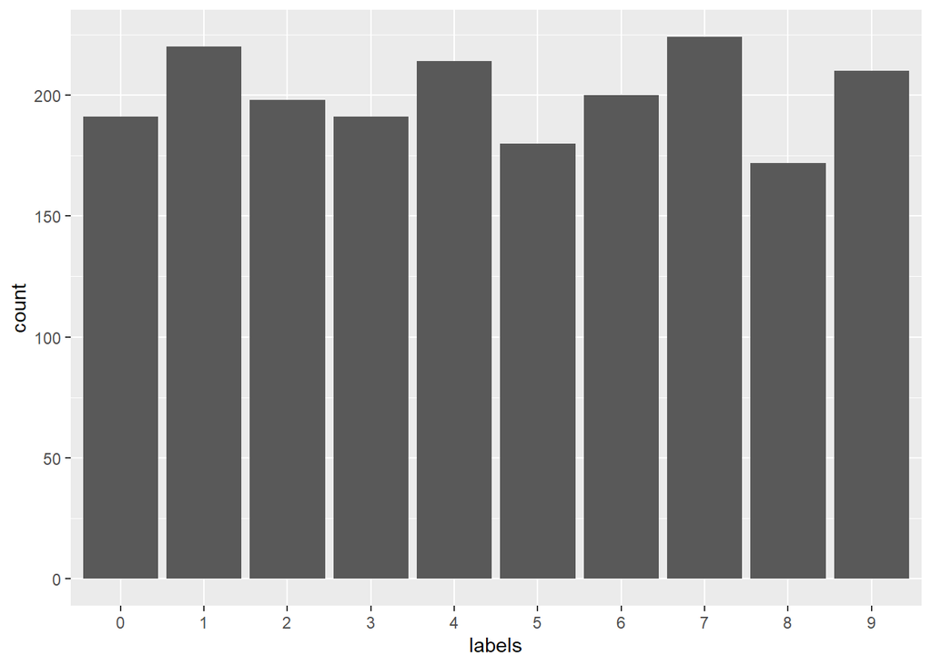

```r
# 시각화
ggplot(as.data.frame(train_y), aes(x=train_y)) + geom_bar() + labs(x="labels")
```

- 0 ~ 9 값을 가지는 label의 개수가 172 ~ 224개까지 범위를 가지기 때문에 label별로 조금 차이는 있으나 분석에는 크게 무리가 없을 것으로 판단된다.

**C. train_x의 column의 이름을 V1, V2, V3 … 순서대로 설정하자. colnames() 함수를 사용한다.**

```r
# 1C. train_x의 변수 이름 세팅
colnames(train_x) <- paste0("V", 1:ncol(train_x))
```

**D. 784개의 픽셀 중에서 숫자와 관련없는 가장자리 부분과 같은 경우는 많은 데이터들에 대해서 같은 색을 가진다. 이러한 픽셀은 숫자를 분류하는 데 크게 영향을 미치지 않으므로 feature에서 제외시키는 것이 합리적이다. caret 패키지의 nearZeroVar(train_x) 함수를 실행하면 train_x의 column들 중에서 variance가 0이거나 0에 가까운 것들의 index를 얻을 수 있다. 이 index에 해당하는 column을 train_x에서 제외시키자. 784개의 feature 중에서 몇개가 제외되었는가?**

```r
# 1D. variance가 0에 가까운 feature 제외
nzv <- nearZeroVar(train_x)
length(nzv)
```

```
## [1] 540
```

```r
train_x <- train_x[, -nzv]
```

- 784개의 픽셀 중에서 540개가 feature에서 제외되었다.

**E. 최종적으로 train_x와 train_y를 합쳐서 train이라는 이름의 데이터프레임을 만들자.**

```r
# 1E. training set data frame 생성
train <- data.frame(train_x, y = train_y)
```

**F. C~E의 과정을 test set에 대해서 동일하게 수행하여 test라는 이름의 데이터프레임을 만들자. 이때 D에서 제외한 feature와 동일한 feature들을 test set에서도 제외시켜야 한다.**

```r
# 1F. test set data frame 생성
test_x <- mnist$test$images
test_y <- mnist$test$labels
colnames(test_x) <- paste0("V", 1:ncol(test_x))
test_x <- test_x[, -nzv]
test <- data.frame(test_x, y = test_y)
```

#### 2. 아래의 코드는 test set의 첫번째 데이터를 화면에 이미지로 출력해준다. 이를 활용하여 test set의 image 행렬의 행 번호를 입력받아 숫자 이미지를 출력하는 함수 print_image()를 만들어보자. 이 함수를 활용하여 9, 19, 42번째 숫자를 이미지로 출력해보고 실제 label 값과 비교해보자.

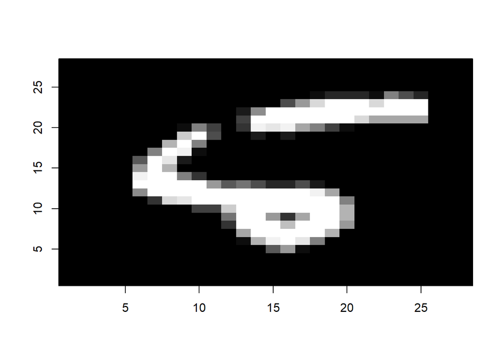

```r
# 2. 이미지 출력 함수 작성
print_image <- function(num){image(1:28, 1:28, matrix(mnist$test$images[num,], nrow=28)[ , 28:1], col = gray(seq(0, 1, 0.05)), xlab = "", ylab="")}

# 이미지와 실제 label 비교
print_image(9)
```

[figure not shown]

```r
print_image(19)
```

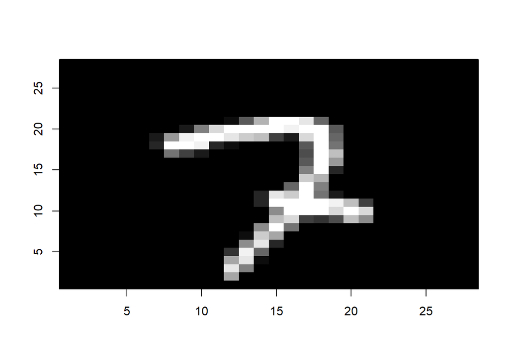

```r
print_image(42)
```

```r
test_y[9]
```

```
## [1] 5
```

```r
test_y[19]
```

```
## [1] 3
```

```r
test_y[42]
```

```
## [1] 7
```

#### Decision tree를 만들어보자.

##### A.rpart() 함수의 default 옵션으로 Tree를 만든 후 cross validation을 활용한 pruning 과정을 수행해보자.

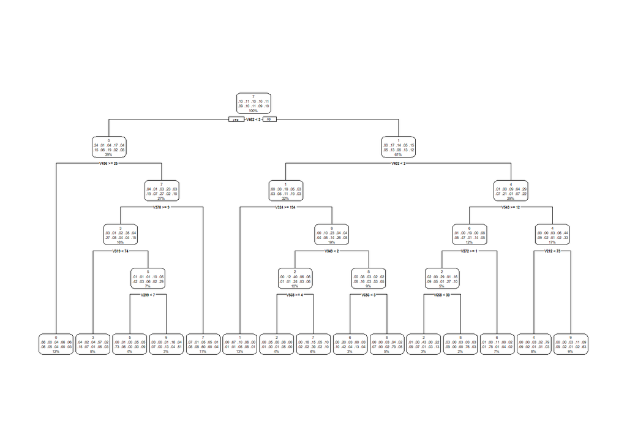

```r
set.seed(123)

tree = rpart(y~.,data=train,method="class")
rpart.plot(tree)
```

```r
# cross validation의 결과 출력
printcp(tree)
```

```
##
## Classification tree:
## rpart(formula = y ~ ., data = train, method = "class")
##
## Variables actually used in tree construction:
##  [1] V212 V272 V299 V319 V324 V349 V378 V402 V456 V462 V543 V568 V656 V658
##
## Root node error: 1776/2000 = 0.888
##
## n= 2000
##
##          CP nsplit rel error  xerror      xstd
## 1  0.099099      0   1.00000 1.01239 0.0075877
## 2  0.094032      1   0.90090 0.96903 0.0087244
## 3  0.067005      2   0.80687 0.80912 0.0113246
## 4  0.056306      3   0.73986 0.70721 0.0121709
## 5  0.052365      4   0.68356 0.66385 0.0123871
## 6  0.051802      5   0.63119 0.63908 0.0124752
## 7  0.038570      6   0.57939 0.58559 0.0125804
## 8  0.025901      8   0.50225 0.53378 0.0125734
## 9  0.016892      9   0.47635 0.49718 0.0125040
## 10 0.016329     10   0.45946 0.47185 0.0124242
## 11 0.014077     11   0.44313 0.46509 0.0123984
## 12 0.011261     13   0.41498 0.44426 0.0123070
## 13 0.010000     14   0.40372 0.43131 0.0122409
```

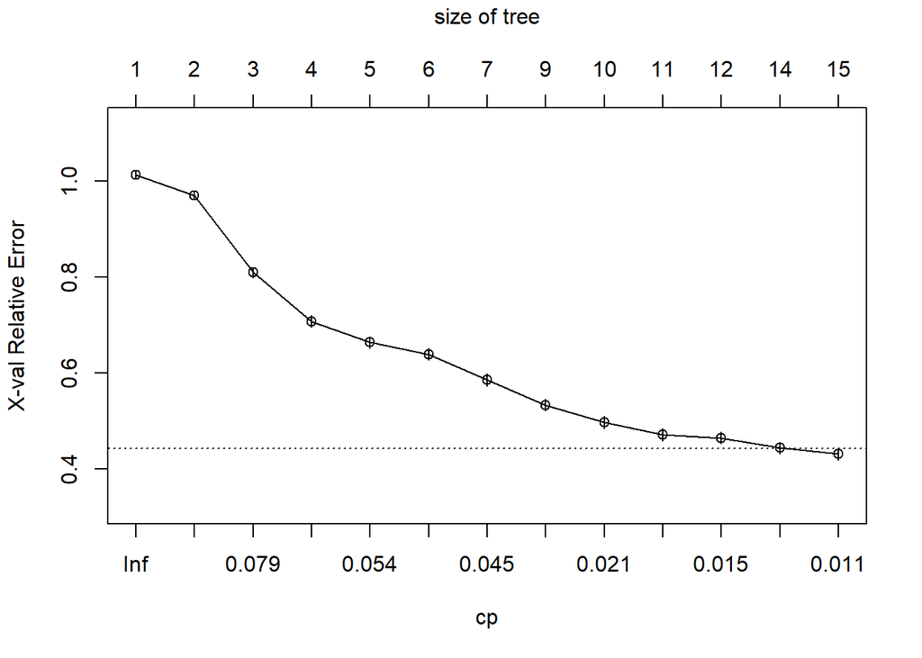

```r
# cross validation의 결과를 시각화
plotcp(tree)
```

```r
# cv error가 가장 낮을 떄, cp값 저장
best_cp=tree$cptable[which.min(tree$cptable[,"xerror"]),"CP"]

best_cp
```

```
## [1] 0.01
```

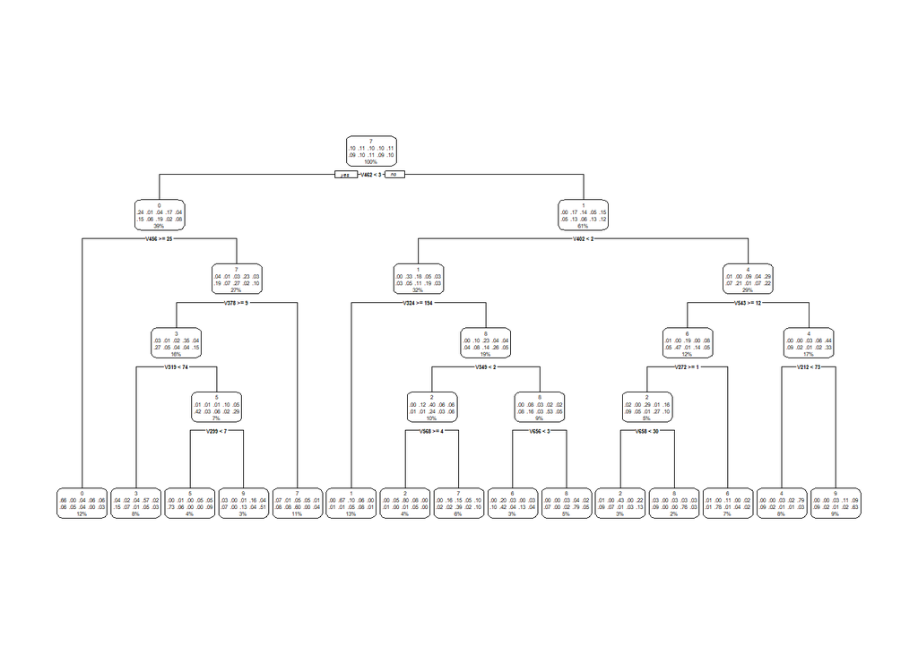

```r
# best cp 값일 때, pruned tree 생성 및 시각화
best_rt = prune(tree, cp = best_cp)
rpart.plot(best_rt)
```

CV 예측오차를 최소화하는 best cp = 0.01이다.

##### B. Pruning을 통해 얻은 Tree의 Test set에 대한 정확도는 얼마인가?

```r
# test set에 대한 예측 수행 및 confusion matrix 계산
pred_class=predict(best_rt, newdata = test,type="class")
confusionMatrix(factor(pred_class),factor(test$y))
```

```
## Confusion Matrix and Statistics
##
##           Reference
## Prediction   0   1   2   3   4   5   6   7   8   9
##          0 760   0  43  38  45  54 113  30  20  40
##          1   0 856 181  90   5  15   7  54 143  17
##          2   5  28 454  17  46  33  52  32  21  25
##          3  20  11  24 466  30 110  42   4  33  51
##          4   1   0  19  18 531  64  29  15  23  61
##          5   6   2   1  61  12 269  18   3  11  37
##          6   1  96  48  15  42  36 566   4  77  23
##          7 158 136 237 111  91  82 108 845  23 110
##          8  12   5   6  32  23  70  11  14 541  27
##          9  17   1  19 162 157 159  12  27  82 618
##
## Overall Statistics
##
##                Accuracy : 0.5906
##                  95% CI : (0.5809, 0.6003)
##     No Information Rate : 0.1135
##     P-Value [Acc > NIR] : < 2.2e-16
##
##                   Kappa : 0.5444
##
##  Mcnemar's Test P-Value : NA
##
## Statistics by Class:
##
##                      Class: 0 Class: 1 Class: 2 Class: 3 Class: 4 Class: 5
## Sensitivity            0.7755   0.7542   0.4399   0.4614   0.5407   0.3016
## Specificity            0.9575   0.9422   0.9711   0.9638   0.9745   0.9834
## Pos Pred Value         0.6649   0.6257   0.6367   0.5891   0.6978   0.6405
## Neg Pred Value         0.9752   0.9677   0.9378   0.9409   0.9512   0.9350
## Prevalence             0.0980   0.1135   0.1032   0.1010   0.0982   0.0892
## Detection Rate         0.0760   0.0856   0.0454   0.0466   0.0531   0.0269
## Detection Prevalence   0.1143   0.1368   0.0713   0.0791   0.0761   0.0420
## Balanced Accuracy      0.8665   0.8482   0.7055   0.7126   0.7576   0.6425
##                      Class: 6 Class: 7 Class: 8 Class: 9
## Sensitivity            0.5908   0.8220   0.5554   0.6125
## Specificity            0.9622   0.8823   0.9778   0.9293
## Pos Pred Value         0.6233   0.4445   0.7301   0.4928
## Neg Pred Value         0.9569   0.9774   0.9532   0.9553
## Prevalence             0.0958   0.1028   0.0974   0.1009
## Detection Rate         0.0566   0.0845   0.0541   0.0618
## Detection Prevalence   0.0908   0.1901   0.0741   0.1254
## Balanced Accuracy      0.7765   0.8521   0.7666   0.7709
```

Test Set에 대한 예측 정확도는 59.06% 이다.

##### C. randomForest() 함수를 사용하여 bagging model을 만들어보자. mtry를 제외한 옵션은 모두 default 값을 사용한다.

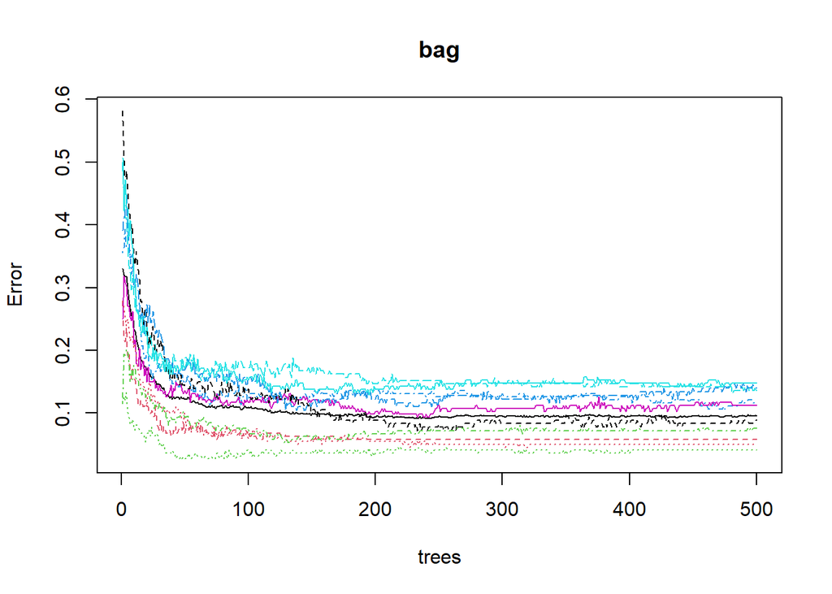

```r
set.seed(123)

# bagging model
bag=randomForest(y~.,data=train,mtry=ncol(train)-1)
plot(bag)
```

##### D. Bagging model의 Test set에 대한 정확도는 얼마인가? B번의 Tree model에 비해서 성능이 얼마나 향상되었는가?

```r
# test set에 대한 예측 수행 및 confusion matrix 계산
pred_bag=predict(bag,newdata=test,type="class")
confusionMatrix(factor(pred_bag),factor(test$y))
```

```
## Confusion Matrix and Statistics
##
##           Reference
## Prediction    0    1    2    3    4    5    6    7    8    9
##          0  940    0    9    4    1   17   21    0    7    5
##          1    0 1107    3    0    2    8    3    7    7    4
##          2    0    7  929   27    4    1   24   33   15   10
##          3    3    6    8  832    2   16    0    6   23   15
##          4    3    0   14    2  866   10   25    3   13   27
##          5   10    1   10   84    2  800   17    1   26   16
##          6    9    3   16    5   19   10  858    0   27    8
##          7   11    1   26   28    1   11    2  922    5   12
##          8    2   10   11   17   12   11    7    4  802    3
##          9    2    0    6   11   73    8    1   52   49  909
##
## Overall Statistics
##
##                Accuracy : 0.8965
##                  95% CI : (0.8904, 0.9024)
##     No Information Rate : 0.1135
##     P-Value [Acc > NIR] : < 2.2e-16
##
##                   Kappa : 0.885
##
##  Mcnemar's Test P-Value : NA
##
## Statistics by Class:
##
##                      Class: 0 Class: 1 Class: 2 Class: 3 Class: 4 Class: 5
## Sensitivity            0.9592   0.9753   0.9002   0.8238   0.8819   0.8969
## Specificity            0.9929   0.9962   0.9865   0.9912   0.9892   0.9817
## Pos Pred Value         0.9363   0.9702   0.8848   0.9133   0.8993   0.8273
## Neg Pred Value         0.9956   0.9968   0.9885   0.9804   0.9872   0.9898
## Prevalence             0.0980   0.1135   0.1032   0.1010   0.0982   0.0892
## Detection Rate         0.0940   0.1107   0.0929   0.0832   0.0866   0.0800
## Detection Prevalence   0.1004   0.1141   0.1050   0.0911   0.0963   0.0967
## Balanced Accuracy      0.9760   0.9857   0.9434   0.9075   0.9356   0.9393
##                      Class: 6 Class: 7 Class: 8 Class: 9
## Sensitivity            0.8956   0.8969   0.8234   0.9009
## Specificity            0.9893   0.9892   0.9915   0.9775
## Pos Pred Value         0.8984   0.9048   0.9124   0.8182
## Neg Pred Value         0.9889   0.9882   0.9811   0.9888
## Prevalence             0.0958   0.1028   0.0974   0.1009
## Detection Rate         0.0858   0.0922   0.0802   0.0909
## Detection Prevalence   0.0955   0.1019   0.0879   0.1111
## Balanced Accuracy      0.9424   0.9430   0.9074   0.9392
```

Bagging model의 test set에 대한 정확도는 89.65%로 tree model에 비해 약 30.59% 증가하였다.

##### E. randomForest() 함수의 default 옵션을 사용하여 random forest model을 만들어보자. 그리고 Bagging과 random forest 모델의 Tree의 수의 증가에 따른 OOB classification error rate의 변화를 하나의 그래프에 그려보고 두 모델의 성능을 비교해보자.

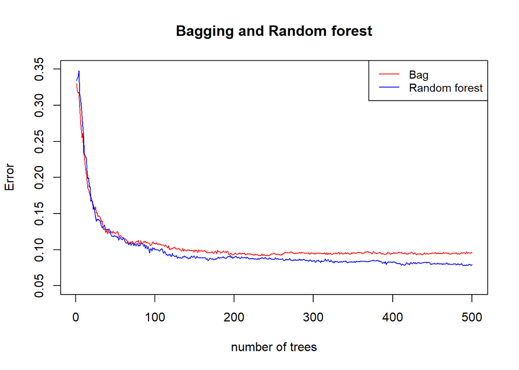

```r
set.seed(123)

# random Forest 모델 생성
rf=randomForest(y~.,data=train)

# OOB classification Error rate 시각화
plot(bag$err.rate[,1],type='l',col="red",ylim=c(0.05,0.35),xlab="number of trees",ylab="Error",main="Bagging and Random forest")
lines(rf$err.rate[,1],type='l',col="blue")
legend("topright",c("Bag","Random forest"),cex=0.9,col=c("red","blue"),lty=1)
```

##### F. Random forest model의 Test set에 대한 예측 정확도는 얼마인가? Bagging model에 비해서 성능이 얼마나 향상되었는가?

```r
# test set에 대한 예측 수행 및 confusion matrix 계산
pred_rf=predict(rf,newdata=test,type="class")
confusionMatrix(factor(pred_rf),factor(test$y))
```

```
## Confusion Matrix and Statistics
##
##           Reference
## Prediction    0    1    2    3    4    5    6    7    8    9
##          0  954    0   10    2    1   16   19    0    9    8
##          1    0 1113    1    0    1   10    3   12    3    5
##          2    3    3  949   24    4    1   22   36    8    7
##          3    0    3    7  882    0   20    0    0   19   15
##          4    5    0   14    2  895   10   16    4   12   20
##          5    7    3    6   57    0  790   12    1   19    9
##          6    7    4   15    5   15   14  882    1   22    5
##          7    3    1   17   18    0    9    1  924    9   10
##          8    1    8   11   12    5    6    3    4  833    4
##          9    0    0    2    8   61   16    0   46   40  926
##
## Overall Statistics
##
##                Accuracy : 0.9148
##                  95% CI : (0.9092, 0.9202)
##     No Information Rate : 0.1135
##     P-Value [Acc > NIR] : < 2.2e-16
##
##                   Kappa : 0.9053
##
##  Mcnemar's Test P-Value : NA
##
## Statistics by Class:
##
##                      Class: 0 Class: 1 Class: 2 Class: 3 Class: 4 Class: 5
## Sensitivity            0.9735   0.9806   0.9196   0.8733   0.9114   0.8857
## Specificity            0.9928   0.9961   0.9880   0.9929   0.9908   0.9875
## Pos Pred Value         0.9362   0.9695   0.8978   0.9323   0.9151   0.8739
## Neg Pred Value         0.9971   0.9975   0.9907   0.9859   0.9904   0.9888
## Prevalence             0.0980   0.1135   0.1032   0.1010   0.0982   0.0892
## Detection Rate         0.0954   0.1113   0.0949   0.0882   0.0895   0.0790
## Detection Prevalence   0.1019   0.1148   0.1057   0.0946   0.0978   0.0904
## Balanced Accuracy      0.9831   0.9883   0.9538   0.9331   0.9511   0.9366
##                      Class: 6 Class: 7 Class: 8 Class: 9
## Sensitivity            0.9207   0.8988   0.8552   0.9177
## Specificity            0.9903   0.9924   0.9940   0.9808
## Pos Pred Value         0.9093   0.9315   0.9391   0.8426
## Neg Pred Value         0.9916   0.9885   0.9845   0.9907
## Prevalence             0.0958   0.1028   0.0974   0.1009
## Detection Rate         0.0882   0.0924   0.0833   0.0926
## Detection Prevalence   0.0970   0.0992   0.0887   0.1099
## Balanced Accuracy      0.9555   0.9456   0.9246   0.9492
```

Random forest model은 91.48%의 예측 정확도가 나왔고, Bagging model에 비해 예측 정확도가 약 1.83% 증가하였다.

##### G. Random forest model의 결과로부터, 분류가 가장 정확한 숫자는 몇인가? 가장 분류가 어려운 숫자는 몇인가?

```r
cm=confusionMatrix(factor(pred_rf),factor(test$y))

# Balanced Accuracy에 해당하는 값들만 따로 추출
Accuracy=data.frame(cm$byClass[,11])
Accuracy
```

```
##          cm.byClass...11.
## Class: 0        0.9831316
## Class: 1        0.9883343
## Class: 2        0.9537654
## Class: 3        0.9330742
## Class: 4        0.9511007
## Class: 5        0.9365669
## Class: 6        0.9554678
## Class: 7        0.9456268
## Class: 8        0.9246267
## Class: 9        0.9492494
```

##### H. 실제 값은 7지만 Random forest model에 의해 1로 예측되는 test data를 찾아 이미지를 몇 개 출력해보자. 눈으로 확인했을 때 7와 1의 구별이 어려운가?

```r
# 실제 값이 7이고 예측값이 1인 데이터 저장
data=subset(test,test$y==7 & pred_rf==1)

# 조건에 해당하는 이미지 번호 추출
rownames(data)
```

```
##  [1] "552"  "1261" "1501" "1717" "2064" "3226" "3581" "3839" "3977" "4298"
## [11] "4887" "4967"
```

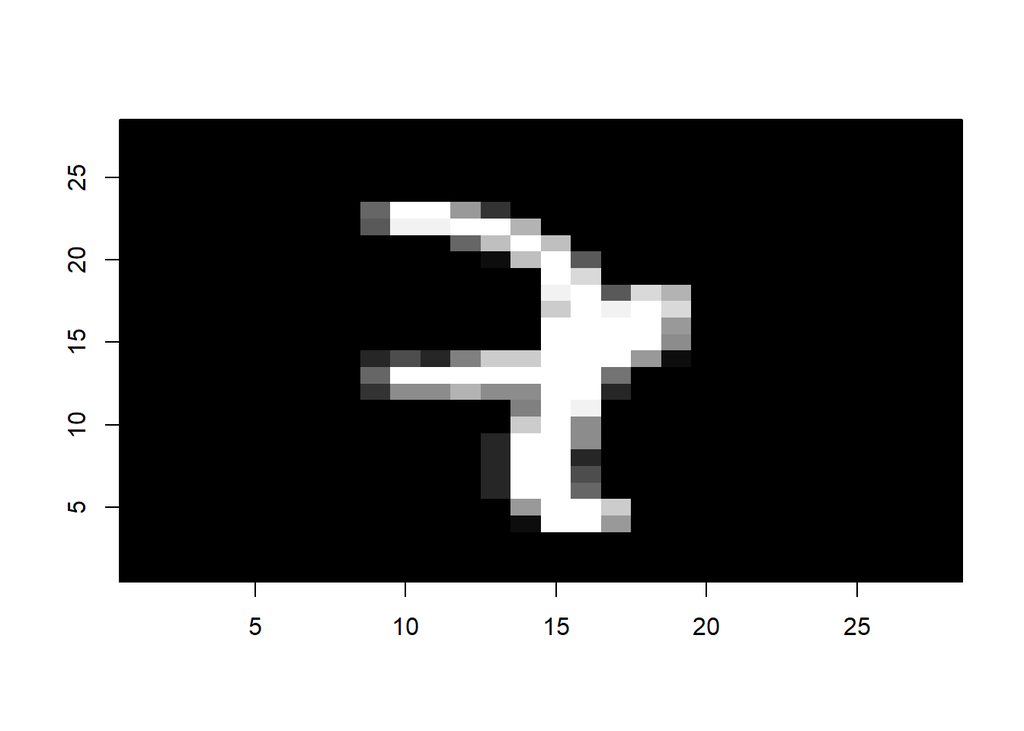

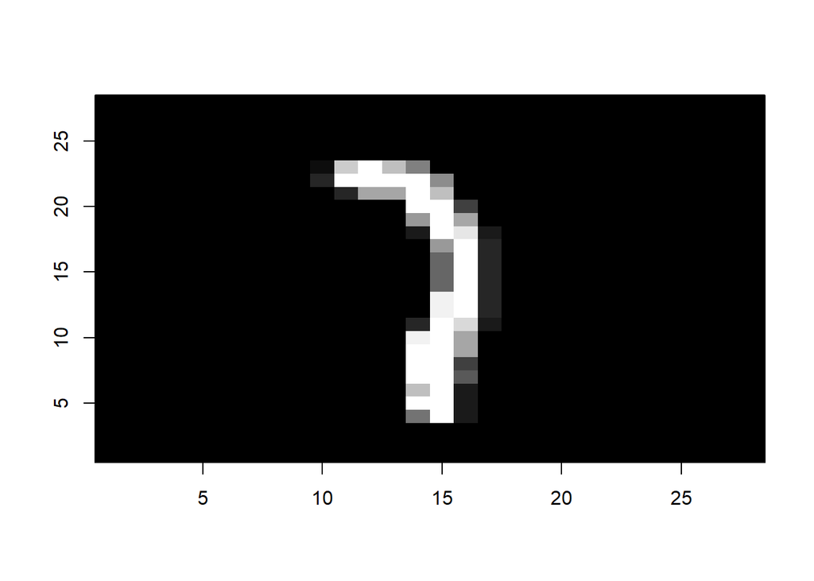

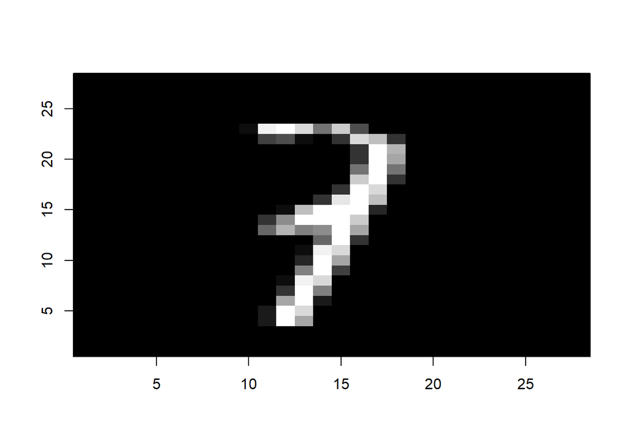

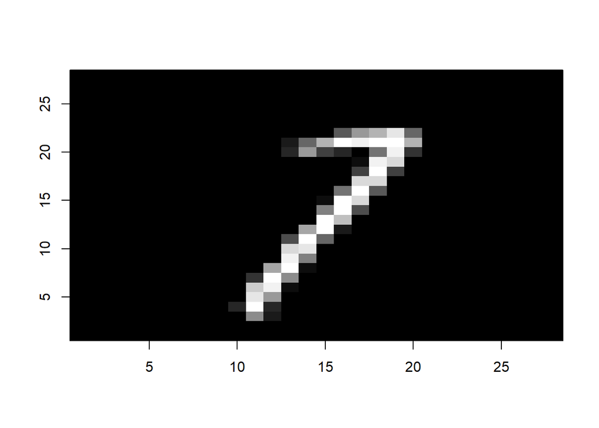

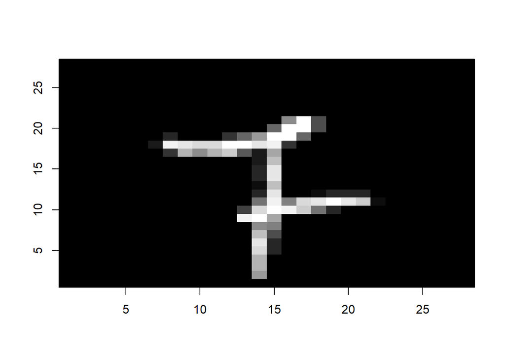

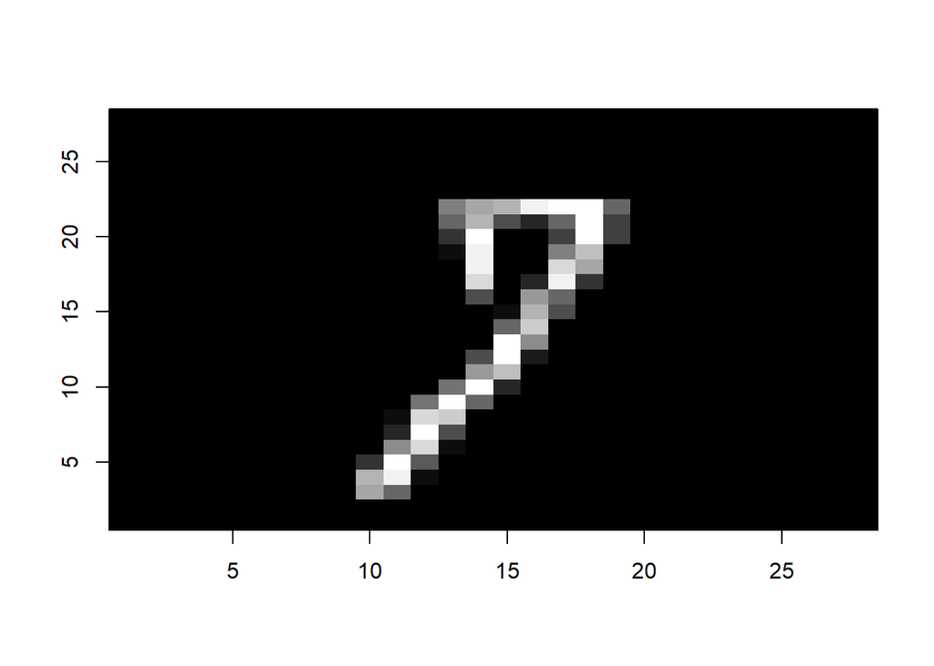

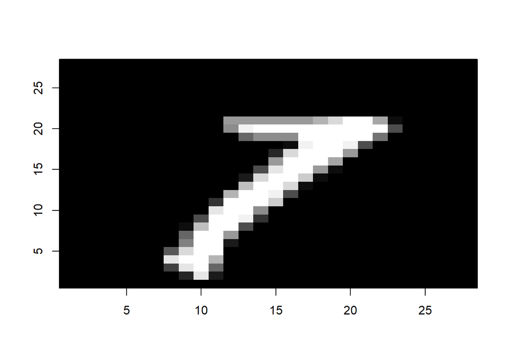

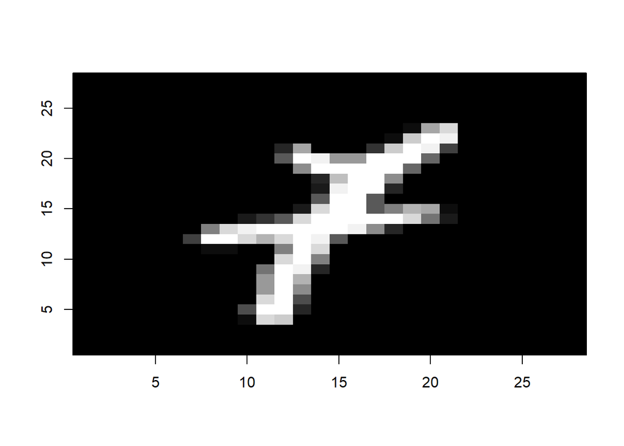

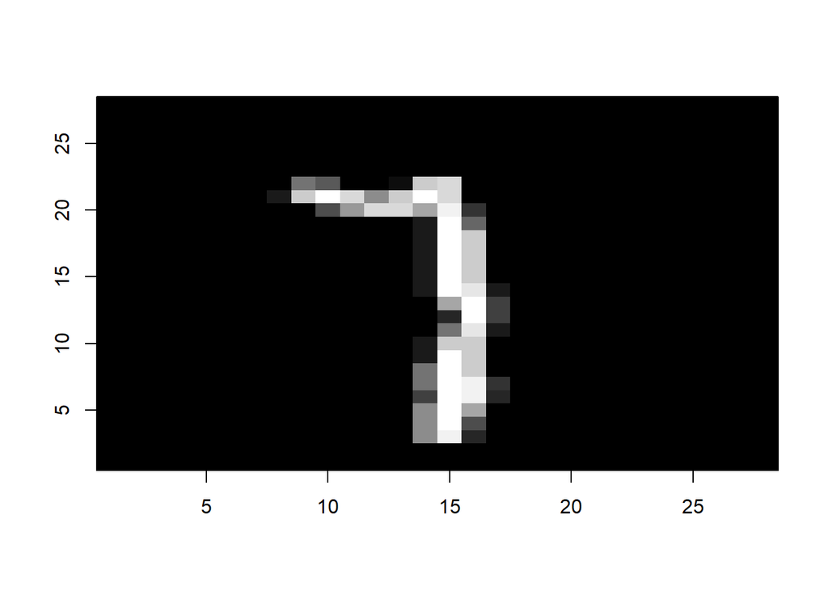

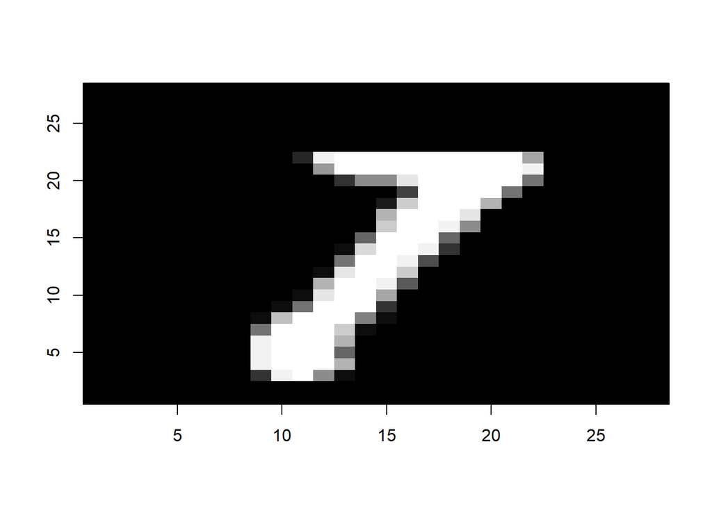

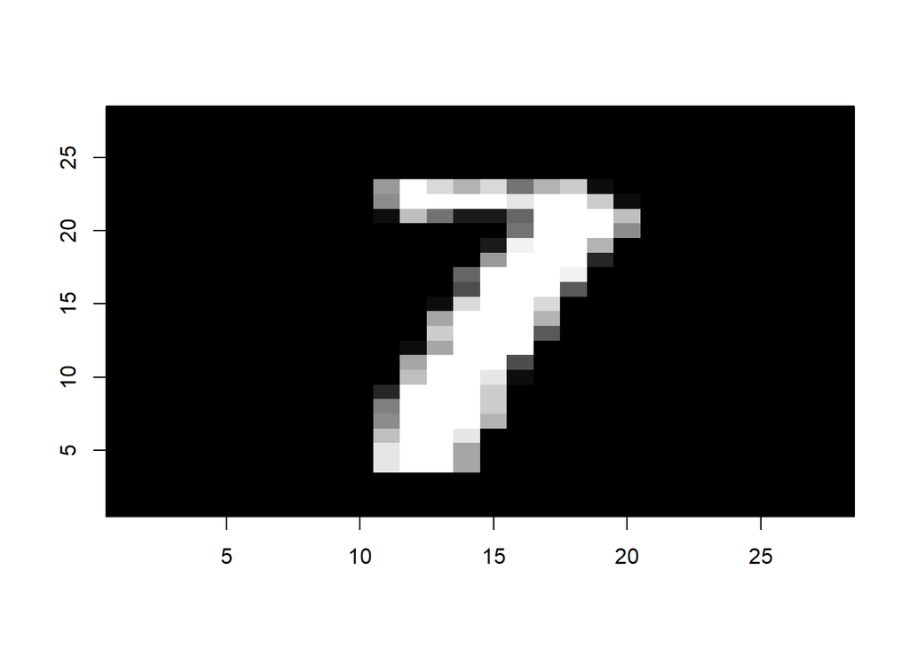

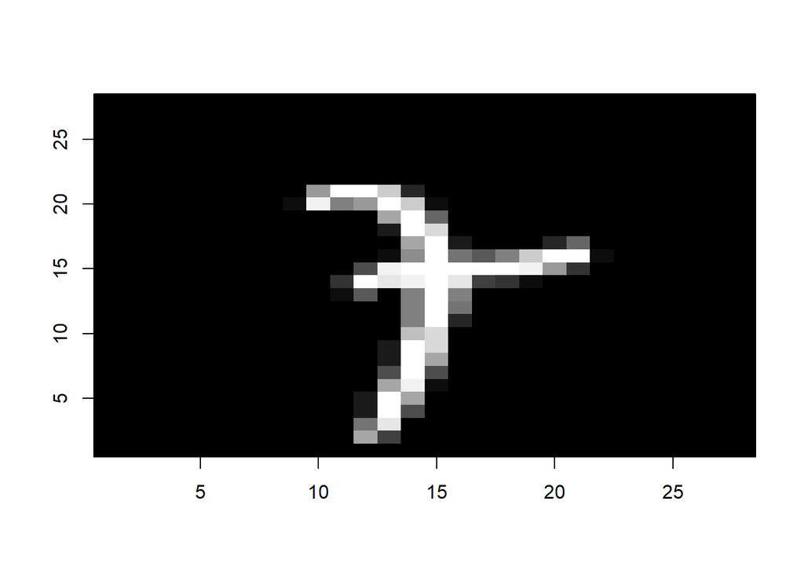

```r
# 이미지
numbers <- c(552, 1261, 1501, 1717, 2064, 3226, 3581, 3839, 3977, 4298, 4887, 4967)

# 반복문으로 각 숫자에 대해 print_image 함수 호출
for (number in numbers) {
  print_image(number)
}
```

개인적으로 이미지들을 확인하였을 때, 1261, 1717, 3581, 4298, 4887 이미지 같은 경우 1인지 7인지 구분하기 모호하다고 판한하였다.